# Análisis de las condiciones del océano frente a Perú durante el año 1991 y relación de la productividad primaria y la temperatura superficial del mar.

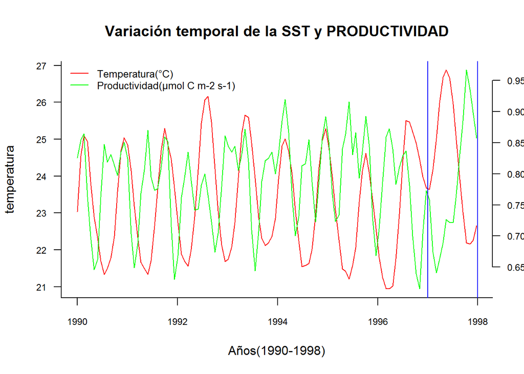

```r
#Variacion temporal de la productividad y temperatura superficial del mar

nc_sst=nc_open("datos/sst.nc4")
nc_sss=nc_open("datos/sss.nc4")
nc_lphy=nc_open("datos/lphy.nc4")
nc_sphy=nc_open("datos/sphy.nc4")
sst = ncvar_get(nc_sst, "to")
lphy = ncvar_get(nc_lphy, "intpp")
sphy = ncvar_get(nc_sphy, "intpp")
sfito = sphy * 10^6
lfito = lphy * 10^6
totalfito = sfito + lfito
tiempo= ncvar_get(nc_sst, "time")
fito_9198=apply(totalfito[,,361:480], MARGIN=3,FUN=mean, na.rm=TRUE)
sst_9198=apply(sst[,,361:480], MARGIN=3,FUN=mean, na.rm=TRUE)
tiempo_9098= seq(1990,1998,0.067)
fito_promedio=apply(totalfito, MARGIN=3,FUN=mean, na.rm=TRUE)

sst_promedio=apply(sst, MARGIN=3,FUN=mean, na.rm=TRUE)

plot(tiempo_9098, sst_9198,type="l", col="red",bty='l',las=1, xlab="Años(1990-1998)",ylab="temperatura", cex.axis=.75)
par(new=TRUE)

plot(tiempo_9098, fito_9198,type="l", col="green",bty='n',xaxt="n",yaxt="n",las=1, xlab="",ylab="")

axis(4, las=1, cex.axis=.75)

legend("topleft",legend=c("Temperatura(°C)","Productividad(µmol C m-2 s-1)"),  col=c("red","green"),lty=1, cex=0.8,bty='n')

title("Variación temporal de la SST y PRODUCTIVIDAD")
abline(v=c(1997:1998),lty=1,col="blue")
```

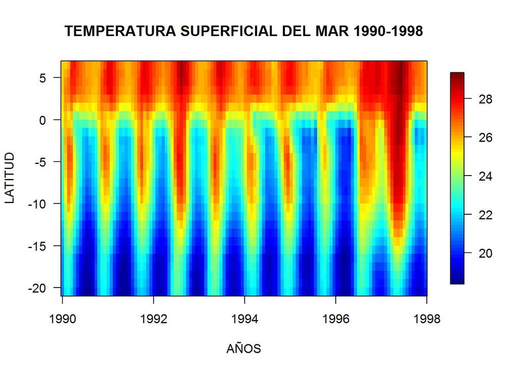

```r
#hovmuller (1990-1998)
hov = apply(sst[,,361:480], MARGIN=c(2,3), FUN = mean, na.rm=TRUE)

image.plot(tiempo_9098, lat, t(hov), las=1, xlab="AÑOS", ylab="LATITUD")
title("TEMPERATURA SUPERFICIAL DEL MAR 1990-1998")
box()
```

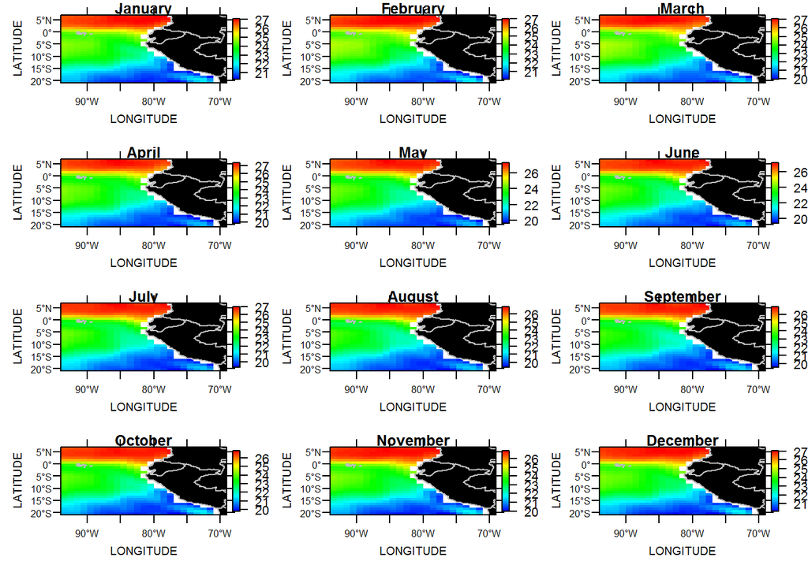

```r
#Variacion mensual de la SST promedio
year1997=tiempo[456:567]
meses=rep(1:12,length=length(year1997))

clima=array(dim=c(dim(sst)[1:2],12))

for(i in 1:12){
  clima[,,i]=apply(sst[,,meses==i],MARGIN=c(1,2),
                  FUN=mean,na.rm=TRUE)}

par(mfrow=c(4,3),mar=c(4,4,1,1))

for(i in 1:12)
  image.map(lon,lat,clima[,,i],main=paste(month.name[i]))
```

La temperatura superficial del mar varia durante el año dependiendo de la estación (fig 8), eso tiene un impacto en la productividad primaria, ya que durante los veranos ocurre la mayor productividad por la mayor irradiancia (figura 6); sin embargo cuando la temperatura superficial del mar aumenta varios grados por encima del promedio como en el Niño 1997 (fig 7) puede afectar negativamente la productividad (fig 6), ya que aguas calidas proviente del centro del pacífico traen menos nutrientes y condiciones negativas para los principales productores (diatomeas).

#### Discusión

El año 1991 tiene un pico positivo y negativo de temperatura superficial del mar normal respecto a los otros años que se dieron niños fuertes o extraordinarios como los 1997-1997 y 1982-1983 (Takahashi K, 2011). Sin embargo a finales de 1991 y durante 1992 se puede observar un pico de temperatura, donde se da la mayor intensidad del denominado Niño 1991-1992 (SENAMHI 2014; Tahakashi, 2016).  
La temperatura y productividad fueron normales durante el año con un pico durante verano y una disminución durante invierno (Morán,2000). La salinidad también fue una variable normal, ya que tiende a disminuir con un aumento de la temperatura superficial del mar durante verano.

## Conclusiones

- No hubo grandes anomalias de temperatura superficial del mar, salinidad y productividad durante el año 1991, por lo tanto es un año normal, sin embargo es previo a El Niño 1992.
- Temperatura superficial del mar mayor al promedio causado por fenomenos como El Niño, puede tener un impacto negativo en la productividad primaria.

## Referencias

-(Morán O. 2000. Caracteristicas del ambiente marino frente a la costa peruana. Bol. Inst. Mar Perú 19(1-2):179-204.)[http://www.imarpe.gob.pe/paita/publicaciones/caract_del_amb_marino.pdf]

-(SENAMHI. 2014. El fenomeno El Niño en el Perú.)[http://www.minam.gob.pe/wp-content/uploads/2014/07/Dossier-El-Niño-Final_web.pdf]

-(Takahashi, K. & Dewitte, B. 2016.Clim Dyn 46: 1627.)[https://link.springer.com/article/10.1007/s00382-015-2665-3]

-(Takahashi, K., A. Montecinos, K. Goubanova y B. Dewitte,2011: ENSO regimes: Reinterpreting the canonical and Modoki El Niño, Geophysical Research Letters.)[http://onlinelibrary.wiley.com/doi/10.1029/2011GL047364/full]